# L08 Positioning

Data Visualization (STAT 302)

## Overview

The goal of this lab is to develop an understanding of facets, position, continue the exploration of other `ggplot2` options/features.

## Datasets

We’ll be using the `titanic.rda`, `Aus_athletes.rda`, and `cdc.txt` datasets.

```r
# Load package(s)

# Load datasets

# Read in the cdc dataset
cdc <- read_delim(file = "data/cdc.txt", delim = "|") %>%
  mutate(genhlth = factor(genhlth,
    levels = c("excellent", "very good", "good", "fair", "poor"),
    labels = c("Excellent", "Very Good", "Good", "Fair", "Poor")
  ))

# Set seed
set.seed(8221984)

# Selecting a random subset of size 1000
cdc_small <- cdc %>% sample_n(1000)
```

## Exercises

Complete the following exercises.

### Exercise 1

Using the `titanic.rda` dataset, recreate the following graphic as precisely as possible.

*Hints:*

- Hex colors: `#D55E00D0`, `#0072B2D0`

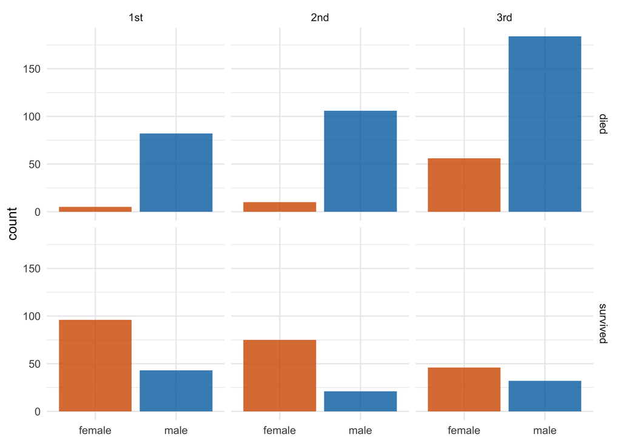

### Exercise 2

Use the `athletes_dat` dataset — extracted from `Aus_althetes.rd` — to recreate the following graphic as precisely as possible. The `cowplot` package will be useful.

```r
# Get list of sports played by BOTH sexes
both_sports <- Aus_athletes %>%
  distinct(sex, sport) %>%
  count(sport) %>%
  filter(n == 2) %>%
  pull(sport)

# Process data
athletes_dat <- Aus_athletes %>%
  filter(sport %in% both_sports) %>%
  mutate(sport = case_when(
    sport == "track (400m)" ~ "track",
    sport == "track (sprint)" ~ "track",
    TRUE ~ sport
  ))
```

*Hints:*

- Build each plot separately
- Use [`cowplot::plot_grid()`](https://cran.r-project.org/web/packages/cowplot/vignettes/plot_grid.html) to combine them
- Hex values for shading: `#D55E0040` and `#0072B240` (bottom plot), `#D55E00D0` & `#0072B2D0` (for top two plots) — no `alpha`
- Hex values for outline of boxplots: `#D55E00` and `#0072B2`
- Boxplots should be made narrower; 0.5
- Legend is in top-right corner of bottom plot
- Legend shading matches hex values for top two plots
- Bar plot lower limit 0, upper limit 95
- `rcc`: red blood cell count; `wcc`: white blood cell count
- Size 3 will be useful

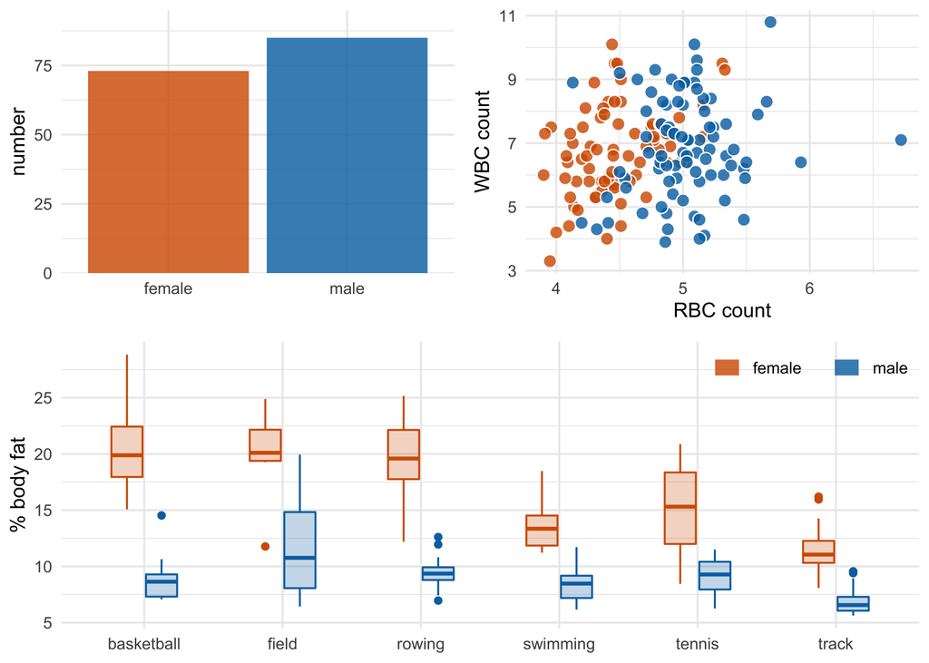

### Exercise 3

Using `cdc_small`construct a the following graphic as precisely as possible.

*Hints:*

- Need to do a little more data processing
- Hex values: `"#D55E00D0"` and `#0072B2D0`
- `grey80` might be useful
- size 2

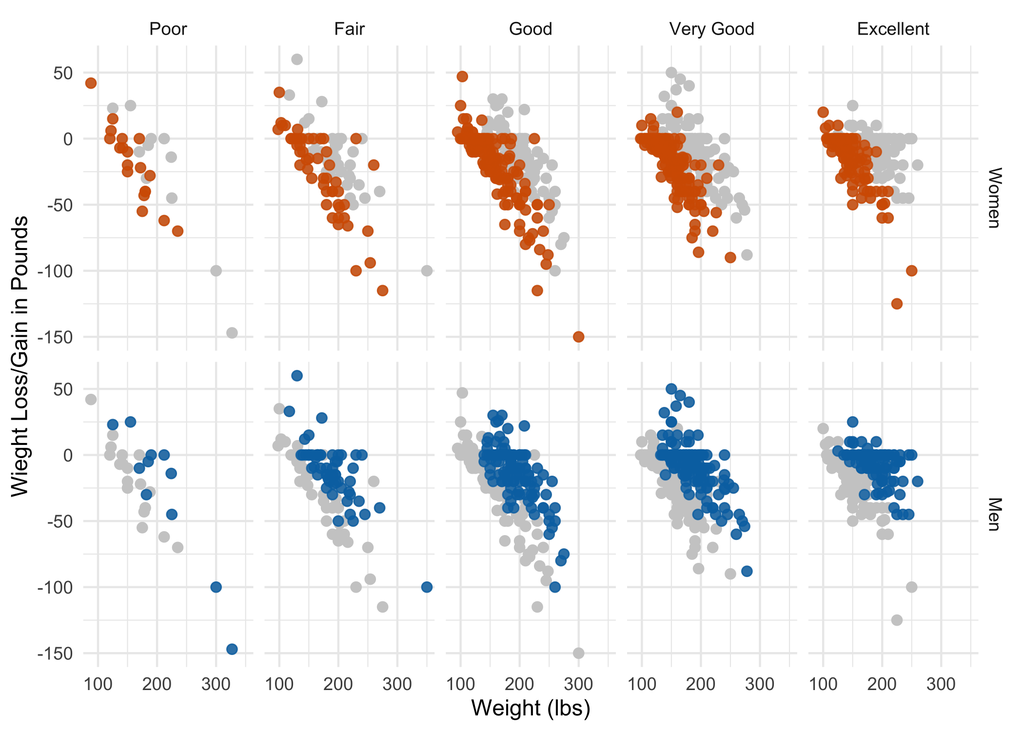